# Prediction Assignment

liuyi647

8 May 2017

## Abstract

One thing that people regularly do is quantify how much of a particular activity they do, but they rarely quantify how well they do it. In this assignment, the goal will be to use data from accelerometers on the belt, forearm, arm, and dumbell of 6 participants, and to predict the manner in which they did the exercise. The predicted variable is the “classe” variable in the training set.

**More Information** http://groupware.les.inf.puc-rio.br/har

**Training Data** https://d396qusza40orc.cloudfront.net/predmachlearn/pml-training.csv

**Test Data** https://d396qusza40orc.cloudfront.net/predmachlearn/pml-testing.csv

## Data Exploratory and Data Process

First of all, the below R code is to downloand the training data and the testing data.

```r
trainUrl = "https://d396qusza40orc.cloudfront.net/predmachlearn/pml-training.csv"
trainFilename = "training.csv"

if(!file.exists(trainFilename)) {
    download.file(trainUrl, destfile=trainFilename)
}

trainRawData <- read.csv(trainFilename)

testUrl = "https://d396qusza40orc.cloudfront.net/predmachlearn/pml-testing.csv"
testFilename = "testing.csv"
if(!file.exists(testFilename)) {
    download.file(testUrl, destfile=testFilename)
}

testRawData <- read.csv(testFilename)
```

The size of two data sets is as below.

```r
dim(trainRawData)
```

```
## [1] 19622   160
```

```r
dim(testRawData)
```

```
## [1]  20 160
```

*classe* variable is a factor predicted variable. The following shows information about the predicted variable.

```r
class(trainRawData$classe)
```

```
## [1] "factor"
```

```r
table(trainRawData$classe)
```

```
##
##    A    B    C    D    E
## 5580 3797 3422 3216 3607
```

The data clean process includes

- Delete those columns which contain missing values.
- Delete those columns which are about time or time window.
- Delete those columns which have near zero variance. Near zero variance variables is not only non-informative, it also can break some models.

```r
library(dplyr)
library(caret)

trainCleanData <- select(trainRawData, -contains("X"), -contains("timestamp"),-contains("window"), -contains("user"))
trainCleanData <- trainCleanData[, colSums(is.na(trainCleanData)) == 0]

nzvColumns <- nearZeroVar(trainCleanData, saveMetrics = TRUE)
trainCleanData <- trainCleanData[, nzvColumns$nzv==FALSE]
```

The processed training data size is as below.

```r
dim(trainCleanData)
```

```
## [1] 19622    41
```

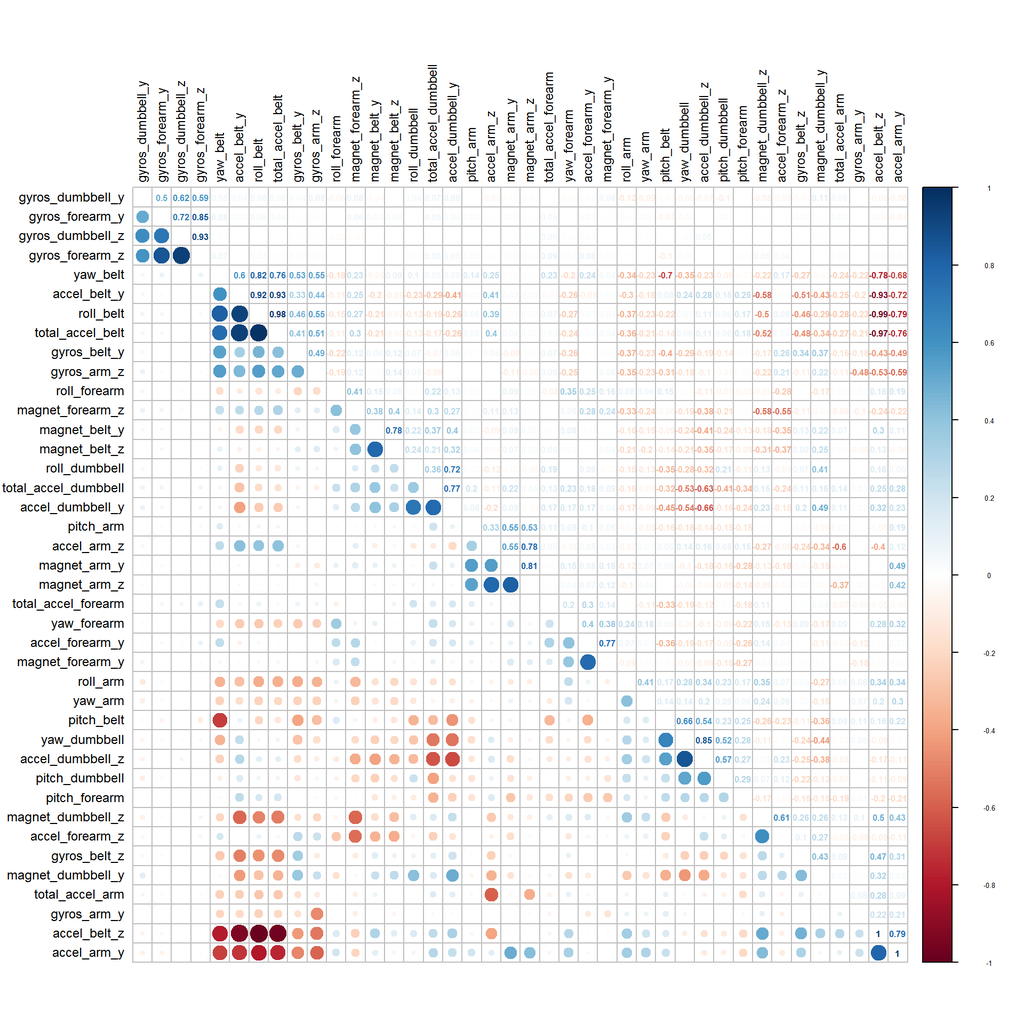

```r
library(corrplot)
corr <- round(cor(trainCleanData[sapply(trainCleanData, is.numeric)]), 2)

par(ps=6)
corrplot.mixed(corr, order = "hclust", tl.col="black", diag = "n", tl.pos = "lt",
               lower = "circle", upper = "number", tl.cex = 1.5, mar=c(1,0,1,0))
```

## Plan

The plan is

- split the training data set into one training set and one validating set
- train a rpart model
- train a random forest model
- compare them and select the best one.

## Data Splitting

The training data are splited into 60% training data and 40% validation data.

```r
set.seed(1254)

forTraining <- createDataPartition(trainCleanData$classe, p=0.60, list=FALSE)
trainingData <- trainCleanData[forTraining,]
validatingData <- trainCleanData[-forTraining,]
```

## Model Selection and Valiation

There are two algorithms which will be selected and tested in this assignment. One is rpart, another one is random forest. We will train two models using each algorithm. One model uses PCA preprocess, and another one doesn’t use PCA preprocess. The final model will be the best one in these four models.

### Rpart Model

Now train the rpart model with the PCA reprocessed data. For a higher process speed, the trainControl is configured as parallel.

The K-fold cross validation is applied as well. The fold number is 5.

```r
library(doParallel)
library(rpart)

cluster <- makeCluster(detectCores() - 1)
registerDoParallel(cluster)

train_control <- trainControl(method="cv", number=5, allowParallel = TRUE)

model_rpart_pca <- train(classe~.,trControl = train_control, preProcess=c("pca"), data=trainingData, method="rpart")
pred_rpart_pca <- predict(model_rpart_pca, validatingData)
(cm_rpart_pca <- confusionMatrix(pred_rpart_pca, validatingData$classe))
```

```
## Confusion Matrix and Statistics
##
##           Reference
## Prediction    A    B    C    D    E
##          A 1632  626  813  402  381
##          B    0    0    0    0    0
##          C    0    0    0    0    0
##          D  389  685  318  705  593
##          E  211  207  237  179  468
##
## Overall Statistics
##
##                Accuracy : 0.3575
##                  95% CI : (0.3469, 0.3682)
##     No Information Rate : 0.2845
##     P-Value [Acc > NIR] : < 2.2e-16
##
##                   Kappa : 0.1694
##  Mcnemar's Test P-Value : NA
##
## Statistics by Class:
##
##                      Class: A Class: B Class: C Class: D Class: E
## Sensitivity            0.7312   0.0000   0.0000  0.54821  0.32455
## Specificity            0.6042   1.0000   1.0000  0.69741  0.86977
## Pos Pred Value         0.4235      NaN      NaN  0.26208  0.35945
## Neg Pred Value         0.8497   0.8065   0.8256  0.88732  0.85116
## Prevalence             0.2845   0.1935   0.1744  0.16391  0.18379
## Detection Rate         0.2080   0.0000   0.0000  0.08985  0.05965
## Detection Prevalence   0.4912   0.0000   0.0000  0.34285  0.16594
## Balanced Accuracy      0.6677   0.5000   0.5000  0.62281  0.59716
```

Surprisely, The overall accuracy is 0.357507, which is very low. Now let’s test rpart model with full data.

```r
model_rpart <- train(classe~.,trControl = train_control, data=trainingData, method="rpart")
pred_rpart <- predict(model_rpart, validatingData)
(cm_rpart <- confusionMatrix(pred_rpart, validatingData$classe))
```

```
## Confusion Matrix and Statistics
##
##           Reference
## Prediction    A    B    C    D    E
##          A 2020  613  633  565  218
##          B   44  537   54  229  191
##          C  163  368  681  492  369
##          D    0    0    0    0    0
##          E    5    0    0    0  664
##
## Overall Statistics
##
##                Accuracy : 0.4973
##                  95% CI : (0.4862, 0.5084)
##     No Information Rate : 0.2845
##     P-Value [Acc > NIR] : < 2.2e-16
##
##                   Kappa : 0.3433
##  Mcnemar's Test P-Value : NA
##
## Statistics by Class:
##
##                      Class: A Class: B Class: C Class: D Class: E
## Sensitivity            0.9050  0.35375   0.4978   0.0000  0.46047
## Specificity            0.6386  0.91814   0.7851   1.0000  0.99922
## Pos Pred Value         0.4989  0.50900   0.3285      NaN  0.99253
## Neg Pred Value         0.9442  0.85554   0.8810   0.8361  0.89160
## Prevalence             0.2845  0.19347   0.1744   0.1639  0.18379
## Detection Rate         0.2575  0.06844   0.0868   0.0000  0.08463
## Detection Prevalence   0.5161  0.13446   0.2642   0.0000  0.08527
## Balanced Accuracy      0.7718  0.63595   0.6415   0.5000  0.72985
```

The overall accuracy is 0.4973235, which is lower than 0.5. The next one is the random forest with PCA compressed data.

```r
model_rf_pca<- train(classe~., trControl = train_control, preProcess=c("pca"), data=trainingData, method="rf")
pred_rf_pca <- predict(model_rf_pca, validatingData)
(cm_rf_pca <- confusionMatrix(pred_rf_pca, validatingData$classe))
```

```
## Confusion Matrix and Statistics
##
##           Reference
## Prediction    A    B    C    D    E
##          A 2213   38    0    1    7
##          B   12 1447   27    0   22
##          C    0   25 1318   63   14
##          D    3    5   19 1218   11
##          E    4    3    4    4 1388
##
## Overall Statistics
##
##                Accuracy : 0.9666
##                  95% CI : (0.9624, 0.9705)
##     No Information Rate : 0.2845
##     P-Value [Acc > NIR] : < 2.2e-16
##
##                   Kappa : 0.9577
##  Mcnemar's Test P-Value : NA
##
## Statistics by Class:
##
##                      Class: A Class: B Class: C Class: D Class: E
## Sensitivity            0.9915   0.9532   0.9635   0.9471   0.9626
## Specificity            0.9918   0.9904   0.9843   0.9942   0.9977
## Pos Pred Value         0.9796   0.9595   0.9282   0.9697   0.9893
## Neg Pred Value         0.9966   0.9888   0.9922   0.9897   0.9916
## Prevalence             0.2845   0.1935   0.1744   0.1639   0.1838
## Detection Rate         0.2821   0.1844   0.1680   0.1552   0.1769
## Detection Prevalence   0.2879   0.1922   0.1810   0.1601   0.1788
## Balanced Accuracy      0.9916   0.9718   0.9739   0.9707   0.9801
```

The overall accuracy is 0.9666072, which is very good result. The final model is the random forest with full data.

```r
model_rf<- train(classe~., trControl = train_control, data=trainingData, method="rf")
pred_rf <- predict(model_rf, validatingData)
(cm_rf <- confusionMatrix(pred_rf, validatingData$classe))
```

```
## Confusion Matrix and Statistics
##
##           Reference
## Prediction    A    B    C    D    E
##          A 2229   20    0    0    0
##          B    1 1492   16    0    0
##          C    0    6 1348   18    0
##          D    1    0    4 1266    1
##          E    1    0    0    2 1441
##
## Overall Statistics
##
##                Accuracy : 0.9911
##                  95% CI : (0.9887, 0.993)
##     No Information Rate : 0.2845
##     P-Value [Acc > NIR] : < 2.2e-16
##
##                   Kappa : 0.9887
##  Mcnemar's Test P-Value : NA
##
## Statistics by Class:
##
##                      Class: A Class: B Class: C Class: D Class: E
## Sensitivity            0.9987   0.9829   0.9854   0.9844   0.9993
## Specificity            0.9964   0.9973   0.9963   0.9991   0.9995
## Pos Pred Value         0.9911   0.9887   0.9825   0.9953   0.9979
## Neg Pred Value         0.9995   0.9959   0.9969   0.9970   0.9998
## Prevalence             0.2845   0.1935   0.1744   0.1639   0.1838
## Detection Rate         0.2841   0.1902   0.1718   0.1614   0.1837
## Detection Prevalence   0.2866   0.1923   0.1749   0.1621   0.1840
## Balanced Accuracy      0.9975   0.9901   0.9908   0.9918   0.9994
```

The overall accuracy is 0.9910783, which is the best one. The out of sample error is 1 - 0.991 = 0.009 = 0.9%.

## Prediction on Testing Data

The selected model is *model_rf*. The prediction result is

```r
pred_final <- predict(model_rf, testRawData)
pred_final
```

```
##  [1] B A B A A E D B A A B C B A E E A B B B
## Levels: A B C D E
```